# Recent Infection Test Calibration (Estimating MDRI and FRR)

Eduard Grebe

2016-05-03

This vignette covers the use of functions $mdrical$ and $frrcal$.

## Introduction

Incidence estimates from cross-sectional surveys using biomarkers for ‘recent infection’ require that the test for recent infection (usually an adapted diagnostic assay) be accurately characterised (which we term calibration). The two critical parameters of test performance are the Mean Duration of Recent Infection (MDRI), denoted $\Omega_T$, (with $T$ the recency cutoff time), and False Recent Rate (FRR), denoted $\Beta_T$. The explicit time cutoff $T$ was introduced by Kassanjee et al. $Epidemiology$, 2012.[^1] to differentiate between ‘true recent’ and ‘false recent’ results. They state:

> To lead to an informative estimator, this cut-off, though theoretically arbitrary, must be chosen to reflect the temporal dynamic range of the test for recent infection; i.e. at a time T post infection, the overwhelming majority of infected people should no longer be testing “recent”, and furthermore, T should not be larger than necessary to achieve this criterion.[^2]

MDRI $\Omega_T$ is defined as the average time alive and returning a ‘recent’ result, while infected for times less than $T$. FRR $\Beta_T$ is defined as the proportion of subjects returning a ‘recent’ result while infected for longer than $T$.

Test performance may be context-specific, and therefore, where available, local data should be used to calibrate tests. However, should published estimates be used, these may need to be adapted to the local context. Often cross-sectional incidence surveys incorporate recency testing using a Recent Infection Testing Algorithms (RITAs) and it is important to realise that the entire RITA must be appropriately calibrated. This may involve adapting MDRI estimates for more sensitive screening tests (depending on the case definition of ‘recent’), or adapting FRR estimates based on weighted estimates from specimen subsets appropriate to the local population (e.g. large numbers of treated individuals). Where possible calibration should be performed using the same set of biomarkers used in a RITA, such as by including a viral load threshold in the calibration step.

## Estimating MDRI using binomial regression

This package provides the function $mdrical$ to estimate MDRI for a given biomarker or set of biomarkers from a dataset of based on the test being applied to well-characterised specimens and subjects. That is, time since ‘infection’ should be well-known, as well as test result(s). Note that ‘infection’ can be arbitrarily defined as the reference time (e.g. the exposure event, date of first detectability on an RNA assay, Western Blot seroconversion, etc.) but should be consistently used. If the reference time used in test calibration differs from the screening assay or algorithm that is used define someone as HIV-positive in a RITA, MDRI needs to be appropriately adapted to cater for this difference.

The following uses example data to demonstrate the use of the function $mdrical$.

Load the package in order to use it

```r
library(abie)
```

```r
exampledata <- read.csv("../data/exampledata_testcalibration.csv")
```

In the following example, subject (panel) identifier and time since estimated date of infection is provided. Then a list of “functional forms” - this parameter can be left out since the default is to use both. The next two paramters are the recency cutoff time aka “Big T” (we usually suggest 2 years) and the data exclusion rule, i.e. all data points beyond this time are ignored in the fitting procedure. The “recency rule” is to tell the function how to distinguish recent from non-recent results. You can classify the data yourself and use “binary_data” as the rule, and then specify the variable in your data frame. We are also specifying a vector of variables and a vector of paramaters to define recency In this case we are using the assay result and the viral load. The paramaters 10,0,1000,1 mean that recency is defined as a biomarker reading below 10 and a viral load reading above 1000 alpha and n_bootstraps relate to obtaining confidence intervals using subject-level bootstrapping.

Here we will use the complementary log-log link $\ln(t)$ as predictor to model $P_R(t)$:

```
## $MDRI
##                      PE    CI_LB    CI_UB      SD
## cloglog_linear 260.4783 238.2665 283.6249 12.3389
##
## $Plots
## $Plots$cloglog_linear
```

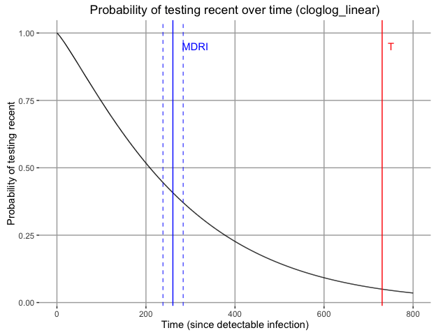

```
##
##
## $Models
## $Models$cloglog_linear
##
## Call:  glm2::glm2(formula = (1 - recency_status) ~ 1 + I(log(time_since_eddi)),
##     family = binomial(link = "cloglog"), data = data, control = glm.control(epsilon = tolerance,
##         maxit = maxit, trace = FALSE))
##
## Coefficients:
##             (Intercept)  I(log(time_since_eddi))
##                  -6.618                    1.170
##
## Degrees of Freedom: 643 Total (i.e. Null);  642 Residual
## Null Deviance:       875.9
## Residual Deviance: 637.5     AIC: 641.5
```

```r
mdrical(data=exampledata,
                 subid_var = "SubjectID",
                 time_var = "DaysSinceEDDI",
                 recency_cutoff_time = 730.5,
                 inclusion_time_threshold = 800,
                 functional_forms = c("cloglog_linear"),
                 recency_rule = "independent_thresholds",
                 recency_vars = c("Result","VL"),
                 recency_params = c(10,0,1000,1),
                 n_bootstraps = 100,
                 alpha = 0.05,
                 plot = TRUE)
```

Here we use the logit link and a cubic polynomial in $t$ to model $P_R(t)$:

```
## $MDRI
##                   PE    CI_LB    CI_UB      SD
## logit_cubic 259.2234 230.4156 284.8815 13.1672
##
## $Plots
## $Plots$logit_cubic
```

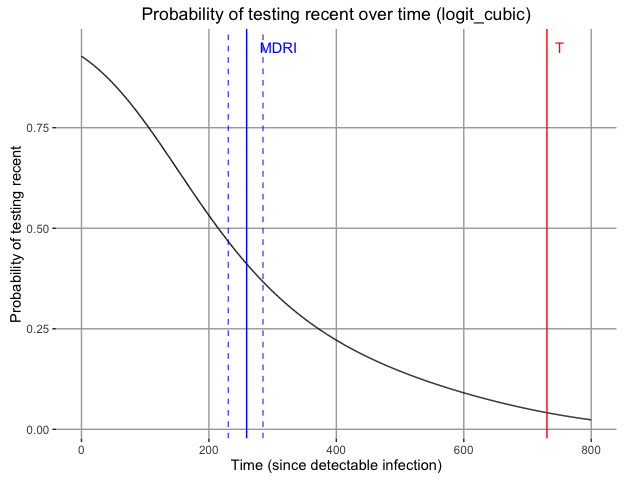

```
##
##
## $Models
## $Models$logit_cubic
##
## Call:  glm2::glm2(formula = recency_status ~ 1 + I(time_since_eddi) +
##     I(time_since_eddi^2) + I(time_since_eddi^3), family = binomial(link = "logit"),
##     data = data, control = glm.control(epsilon = tolerance, maxit = maxit,
##         trace = FALSE))
##
## Coefficients:
##          (Intercept)    I(time_since_eddi)  I(time_since_eddi^2)
##            2.554e+00            -1.591e-02             2.184e-05
## I(time_since_eddi^3)
##           -1.471e-08
##
## Degrees of Freedom: 643 Total (i.e. Null);  640 Residual
## Null Deviance:       875.9
## Residual Deviance: 635.3     AIC: 643.3
```

```r
mdrical(data=exampledata,
                 subid_var = "SubjectID",
                 time_var = "DaysSinceEDDI",
                 recency_cutoff_time = 730.5,
                 inclusion_time_threshold = 800,
                 functional_forms = c("logit_cubic"),
                 recency_rule = "independent_thresholds",
                 recency_vars = c("Result","VL"),
                 recency_params = c(10,0,1000,1),
                 n_bootstraps = 100,
                 alpha = 0.05,
                 plot = TRUE)
```

As above, but parellelise the bootstrapping. In this case, split the job over four cores.

**Note: This only works on Unix (Mac or Linux). On Windows this will result in error messages.**

```
## $MDRI
##                      PE    CI_LB    CI_UB      SD
## logit_cubic    259.2234 231.7515 288.5422 14.5415
## cloglog_linear 260.4783 233.7282 290.1605 14.3782
##
## $Plots
## $Plots$logit_cubic
```

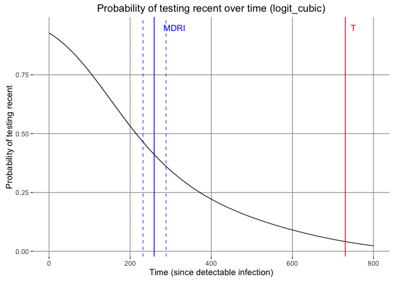

```
##
## $Plots$cloglog_linear
```

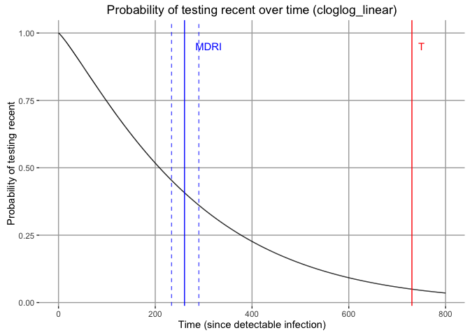

```
##
##
## $Models
## $Models$logit_cubic
##
## Call:  glm2::glm2(formula = recency_status ~ 1 + I(time_since_eddi) +
##     I(time_since_eddi^2) + I(time_since_eddi^3), family = binomial(link = "logit"),
##     data = data, control = glm.control(epsilon = tolerance, maxit = maxit,
##         trace = FALSE))
##
## Coefficients:
##          (Intercept)    I(time_since_eddi)  I(time_since_eddi^2)
##            2.554e+00            -1.591e-02             2.184e-05
## I(time_since_eddi^3)
##           -1.471e-08
##
## Degrees of Freedom: 643 Total (i.e. Null);  640 Residual
## Null Deviance:       875.9
## Residual Deviance: 635.3     AIC: 643.3
##
## $Models$cloglog_linear
##
## Call:  glm2::glm2(formula = (1 - recency_status) ~ 1 + I(log(time_since_eddi)),
##     family = binomial(link = "cloglog"), data = data, control = glm.control(epsilon = tolerance,
##         maxit = maxit, trace = FALSE))
##
## Coefficients:
##             (Intercept)  I(log(time_since_eddi))
##                  -6.618                    1.170
##
## Degrees of Freedom: 643 Total (i.e. Null);  642 Residual
## Null Deviance:       875.9
## Residual Deviance: 637.5     AIC: 641.5
```

```r
mdrical(data=exampledata,
                 subid_var = "SubjectID",
                 time_var = "DaysSinceEDDI",
                 recency_cutoff_time = 730.5,
                 inclusion_time_threshold = 800,
                 functional_forms = c("logit_cubic","cloglog_linear"),
                 recency_rule = "independent_thresholds",
                 recency_vars = c("Result","VL"),
                 recency_params = c(10,0,1000,1),
                 n_bootstraps = 1000,
                 alpha = 0.05,
                 plot = TRUE,
                 parallel = TRUE,
                 cores=4)
```

This example calculates a false-recent rate, treating the data at subject level

```r
frrcal(data=exampledata,
             subid_var = "SubjectID",
             time_var = "DaysSinceEDDI",
             recency_cutoff_time = 730.5,
             recency_rule = "independent_thresholds",
             recency_vars = c("Result","VL"),
             recency_params = c(10,0,1000,1),
             alpha = 0.05)
```

```
##  FRRest     LB     UB alpha n_recent n_subjects n_observations
##  0.0301 0.0131 0.0584  0.05        8        266            732
```

## Styles

```
output:
  rmarkdown::html_vignette:
    css: mystyles.css
```

## Figures

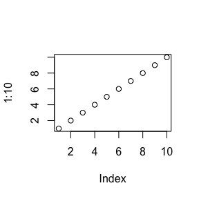

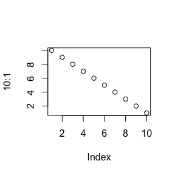

```r
plot(1:10)
plot(10:1)
```

You can enable figure captions by `fig_caption: yes` in YAML:

```
output:
  rmarkdown::html_vignette:
    fig_caption: yes
```

Then you can use the chunk option `fig.cap = "Your figure caption."` in **knitr**.

## More Examples

You can write math expressions, e.g. $Y = X\beta + \epsilon$, footnotes[^3], and tables, e.g. using `knitr::kable()`.

|  | mpg | cyl | disp | hp | drat | wt | qsec | vs | am | gear | carb |
| --- | --- | --- | --- | --- | --- | --- | --- | --- | --- | --- | --- |
| Mazda RX4 | 21.0 | 6 | 160.0 | 110 | 3.90 | 2.620 | 16.46 | 0 | 1 | 4 | 4 |
| Mazda RX4 Wag | 21.0 | 6 | 160.0 | 110 | 3.90 | 2.875 | 17.02 | 0 | 1 | 4 | 4 |
| Datsun 710 | 22.8 | 4 | 108.0 | 93 | 3.85 | 2.320 | 18.61 | 1 | 1 | 4 | 1 |
| Hornet 4 Drive | 21.4 | 6 | 258.0 | 110 | 3.08 | 3.215 | 19.44 | 1 | 0 | 3 | 1 |
| Hornet Sportabout | 18.7 | 8 | 360.0 | 175 | 3.15 | 3.440 | 17.02 | 0 | 0 | 3 | 2 |
| Valiant | 18.1 | 6 | 225.0 | 105 | 2.76 | 3.460 | 20.22 | 1 | 0 | 3 | 1 |
| Duster 360 | 14.3 | 8 | 360.0 | 245 | 3.21 | 3.570 | 15.84 | 0 | 0 | 3 | 4 |
| Merc 240D | 24.4 | 4 | 146.7 | 62 | 3.69 | 3.190 | 20.00 | 1 | 0 | 4 | 2 |
| Merc 230 | 22.8 | 4 | 140.8 | 95 | 3.92 | 3.150 | 22.90 | 1 | 0 | 4 | 2 |
| Merc 280 | 19.2 | 6 | 167.6 | 123 | 3.92 | 3.440 | 18.30 | 1 | 0 | 4 | 4 |

Also a quote using `>`:

> “He who gives up [code] safety for [code] speed deserves neither.” ([via](https://twitter.com/hadleywickham/status/504368538874703872))
[^1]: Kassanjee, Reshma, et al. “A new general biomarker-based incidence estimator.” Epidemiology (Cambridge, Mass.) 23.5 (2012): 721. [URL](http://www.ncbi.nlm.nih.gov/pmc/articles/PMC3500970/)
[^2]: Kassanjee, Reshma, et al. “A new general biomarker-based incidence estimator.” Epidemiology (Cambridge, Mass.) 23.5 (2012): 721. [URL](http://www.ncbi.nlm.nih.gov/pmc/articles/PMC3500970/)
[^3]: A footnote here.